# Results

## 1 Performance overview and key drivers

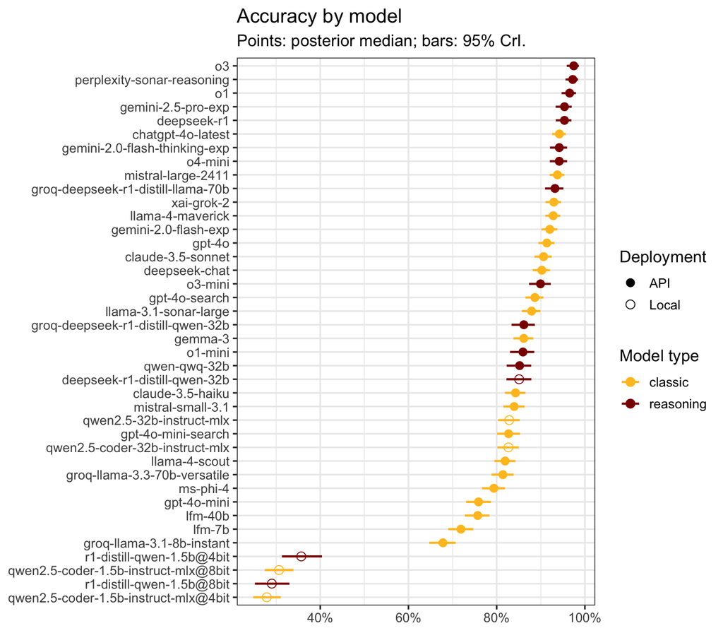

Figure 1: Model accuracy on the travel-medicine benchmark. Points show the posterior median accuracy, with bars representing the 95% credible intervals. Models are ordered by performance.

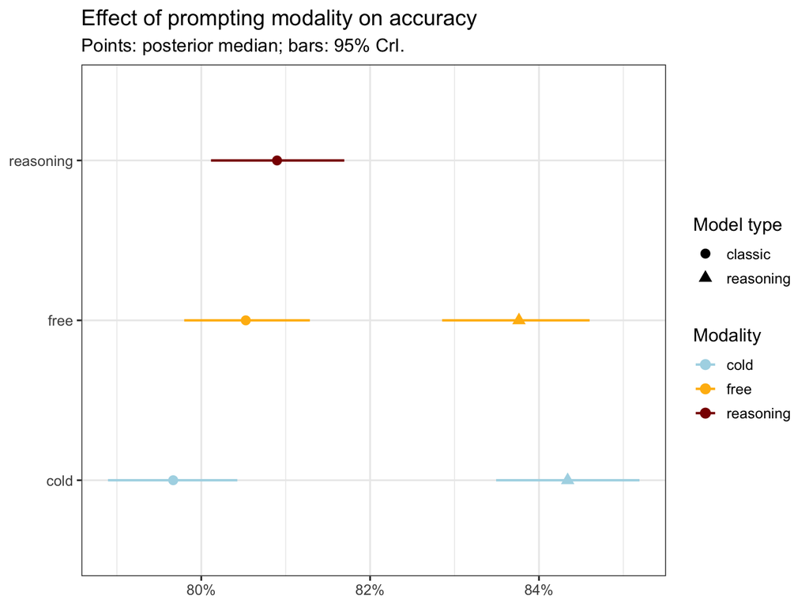

Figure 2: Effect of prompting modality on model accuracy. Points show the posterior median and bars the 95% credible intervals.

Across the 40 large-language models evaluated, posterior accuracy ranged from 97.5% [95.9%-98.6%] for OpenAI’s o3 to 27.9% [24.8%-31.0%] for the smallest local replica (`qwen2.5-coder-1.5b-instruct-mlx@4bit`) (Figure 1).

Large parameter count reasoning models dominated: in addition to o3, o1 96.5% [94.7%-98.0%], Perplexity *Sonar-Reasoning* 97.2% [95.6%-98.5%], and Gemini-2.5-Pro 95.4% [93.4%-97.0%] were among the top performers.

Instruction-tuned classics plateaued roughly 4 percentage points lower, led by GPT-4o 91.4% [89.5%-93.1%] and Mistral-Large-2411 93.8% [92.0%-95.3%].

Local models performed overall worse, mostly due to limits in deployable sizes that restricted deployment to very small models (e.g., 1.5B parameters). The smallest 1.5B quantization languished at 27.9% [24.8%-31.0%]. The largest deployable size on the researchers’ machines was a 32B Qwen distillation of DeepSeek-R1, which achieved 85.1% [82.2%-87.9%] but nevertheless performed slightly worse than the same model accessed via the Groq API (86.2% [83.4%-88.7%]), probably due to the aggressive quantization (4-bit) necessary to make it fit in memory.

Within provider families, accuracy climbed with successive iterations: OpenAI’s line rose from GPT-4o 91.4% [89.5%-93.1%] through o1 96.5% [94.7%-98.0%] to o3 97.5% [95.9%-98.6%]; Google’s advanced from Gemini-Flash 92.0% [90.1%-93.7%] to Gemini-Pro 95.4% [93.4%-97.0%]. Similar improvements were observed for LLama and Mistral models.

Prompting altered these figures only marginally (Figure 2). Classic models improved from 79.7% with a **cold** prompt to 80.9% under explicit reasoning instructions, whereas reasoning models performed best with the concise **cold** prompt (84.3% vs 83.8% for a *free* prompt). But the largest performance gap was between reasoning models and classics, independent of prompt modality.

## 2 Parsability of responses and consistency

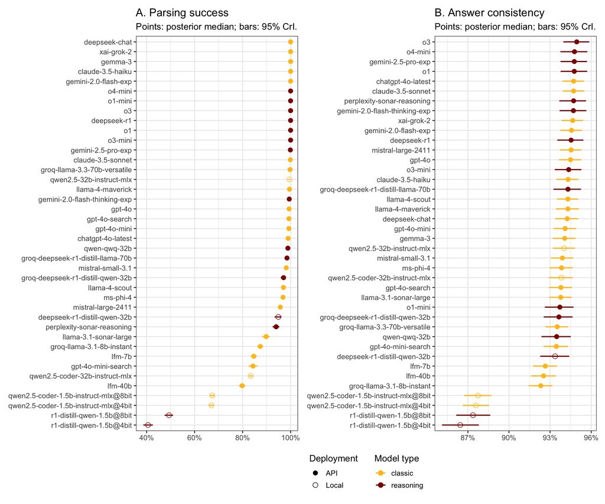

Figure 3: Model performance on secondary metrics. (A) Parsing success, measured as parsing success score. (B) Answer consistency, measuring the reproducibility of answers across identical prompts. Points are posterior medians, bars are 95% credible intervals.

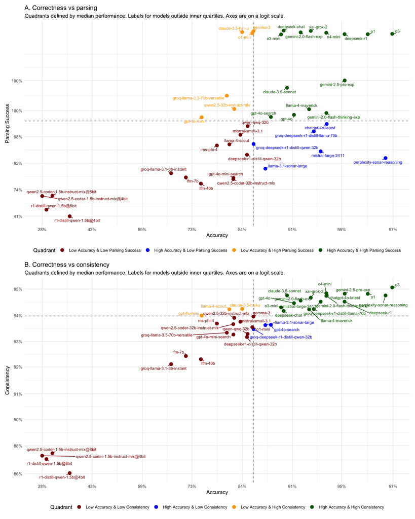

Figure 4: Relationship between accuracy and other performance metrics. (A) Accuracy versus parsing success. (B) Accuracy versus answer consistency. Each point represents a model, categorised into quadrants based on median performance.

Most models followed formatting instructions and produced the expected output format, which allowed for automated parsing of the answers (Figure 3A). Parsability exceeded 90% for 30 of the 40 systems evaluated. The distribution was decidedly bimodal: at one extreme, large high-performing frontier models such as `o3` (100.0%), `gemini-2.5-pro` (99.9%), and `deepseek-r1` (100.0%) yielded perfect rates well above 95%; at the other, small locally-running models showed a strong drop in parsability, achieving barely half that rate with scores around 50%.

In general, accuracy and instruction-following were moderately correlated (r = 0.62; 95% CrI 0.56-0.67). However, a well-structured output did not guarantee correctness. When plotted against each other (Figure 4A), the models divided into four groups: the best models dominated the upper-right (accurate and well-formed) quadrant, while notable exceptions populated the off-diagonal quadrants. For example, GPT-4o Mini and Claude 3.5 Haiku attained an almost perfect parse rate but underperformed in terms of accuracy; on the other hand, Perplexity Sonar Reasoning was extremely reliable in providing correct answers but had more difficulties in following formatting instructions.

## 3 Cost-accuracy trade-off

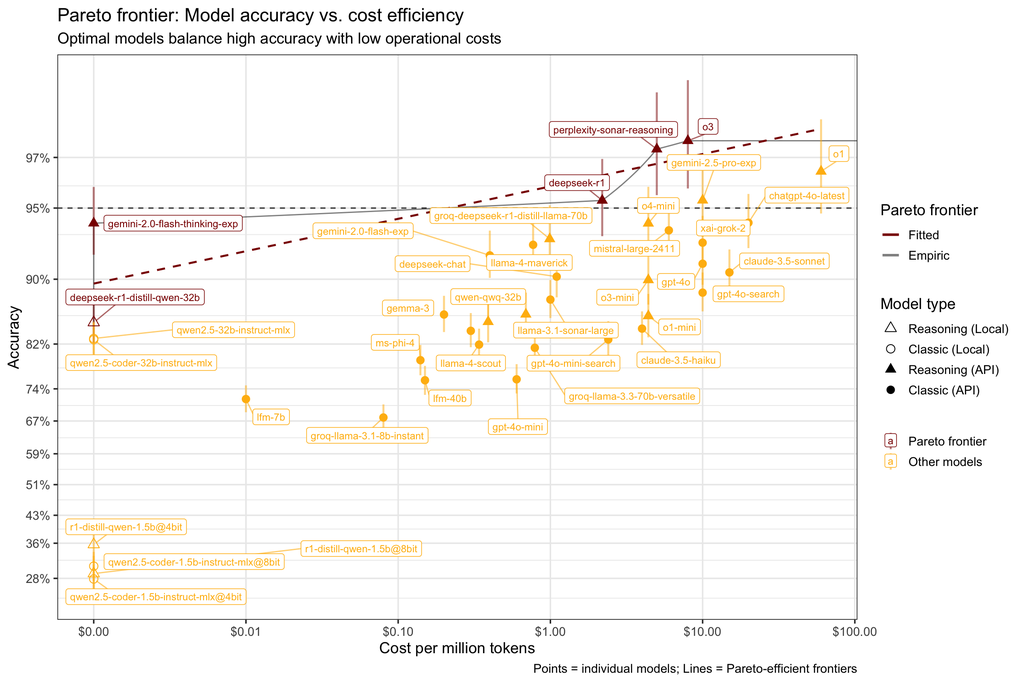

Figure 5: Cost-accuracy trade-off and Pareto frontier. The frontier (red line) highlights models offering the best accuracy for a given cost. The y-axis is on a logit scale and the x-axis on the log10 scale of cost per million tokens.

The cost-accuracy analysis identified 5 Pareto-optimal models (Figure 5) spanning four orders of magnitude in price. Accuracy increased almost monotonically from roughly 85.1% [82.2%-87.9%] for a free local 32-B DeepSeek R1 distillation (at no cost) to 97.5% [95.9%-98.6%] for OpenAI’s o3 (at $8 per million tokens). Crucially, a drastic (~80%) recent price cut for o3 positioned it at the apex of the efficiency frontier.

In contrast, o1 delivers a similar accuracy of 96.5% but at a far steeper cost of $60 per million tokens, leaving it well below the frontier. Intermediate points such as DeepSeek-R1 (95.4% at $2.19) and Perplexity Sonar Reasoning (97.2% at $5) illustrate that large gains in accuracy can be obtained for modest additional spend, whereas costs beyond ≈$10 yield diminishing returns. Overall, Perplexity Sonar Reasoning and o3 currently offer the most favourable balance between accuracy and operational expense, with o3 being more stable and reliable (see Figure 4).

## 4 Item-level analysis

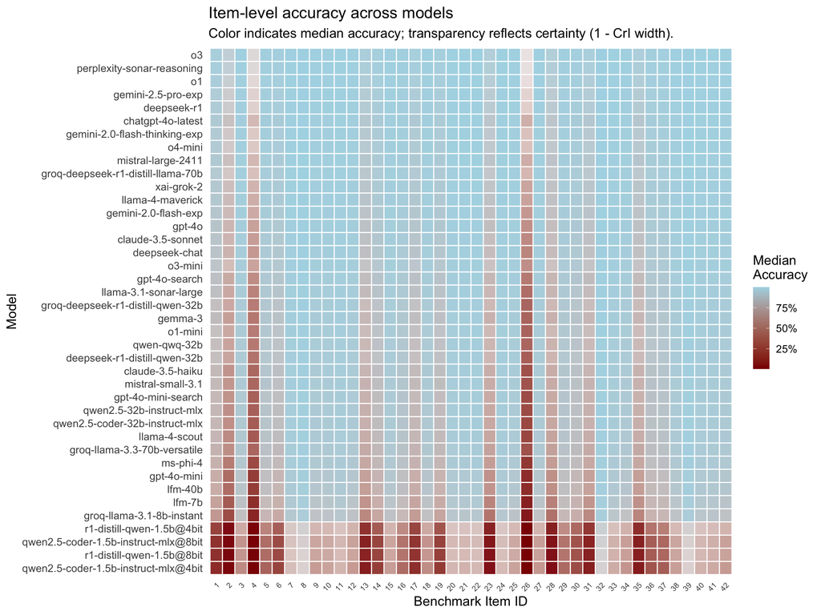

Figure 6: Item-level performance across all models. Each cell shows the median posterior correctness for a given model and question. Color intensity reflects correctness, and transparency indicates certainty (narrower credible intervals are more opaque).

Per-question model performance was highly heterogeneous (Figure 6). Median accuracy spanned from 17.5% for the hardest prompt (item 26, a neurological-symptoms scenario with a past exposure to center-west Africa rural setting, suggestive of Onchocerciasis) up to virtually perfect performance on the easiest trio (#39 (99.1%), #8 (99.2%), #32 (99.4%)), covering routine travel-medicine advice and basic epidemiology.

Only 12% of systems crossed the 50% posterior threshold on item 26. In the raw responses, option A (“Skin snips”) was chosen 40%, D (“Giemsa-stained smears of blood drawn at night”) 32%, and the correct option C (“Antifilarial antibody levels”) only 23%. *o3* was internally consistent yet wrong, selecting A in 100% of its replications. The spread across alternatives indicates genuine uncertainty rather than a single systematic misconception. Notably, solution A is the first-line diagnostic approach for suspected Onchocerciasis.

Notably, for items #2 (diagnosis of suspected malaria with diarrheal symptoms) and #4 (treatment of fever and diarrhea), the second and third most challenging items after #26, the o3 model consistently provided correct responses, yet exhibited posterior medians (approximately 90% and 77%, respectively) far from a 100% success rate and with wider credible intervals. This pattern reflects the regularizing properties of the hierarchical Bayesian model, which exhibits increased uncertainty when a model’s performance substantially deviates from the population average, as each question was modelled with its own intercept and no model/item interaction was included for better generalization.

Conversely, items such as #39 (99.1%), #8 (99.2%), #32 (99.4%) were solved by virtually all systems, indicating that a sizeable fraction of the benchmark targeted plain retrieval rather than complex reasoning. Variation (range of posterior medians) exceeded 90 percentage points for several mid-difficulty questions, underscoring that model architecture and scale interact strongly with item traits. Overall, a small subset of challenging prompts (e.g., items #26 (17.5%), #4 (24.4%), #2 (46.2%)) accounted for the bulk of performance discrimination across models.